# BDA507 LAB WORK WEEK-16

Task-16A: Please rotate the faces plot and this time the columns (not the rows) will include the photos of the same person. Please provide the pseudocode first and then the full code please.

```python
import matplotlib.pyplot as plt
plt.style.use('classic')
%matplotlib inline
import numpy as np
```

```
downloading Olivetti faces from https://ndownloader.figshare.com/files/5976027 to C:\Users\NERIMAN.GURSOY\scikit_learn_data
```

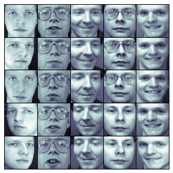

```python
fig, ax = plt.subplots(5, 5, figsize=(5, 5))
fig.subplots_adjust(hspace=0, wspace=0)

# Get some face data from scikit-learn
from sklearn.datasets import fetch_olivetti_faces
faces = fetch_olivetti_faces().images

for i in range(5):
    for j in range(5):
        ax[i, j].xaxis.set_major_locator(plt.NullLocator())
        ax[i, j].yaxis.set_major_locator(plt.NullLocator())
        ax[i, j].imshow(faces[10 * j + i], cmap="bone")
```

Task-16B: Please plot 3 figures next to each other and the first one shall be a scatter plot, the second one a line plot and the third one a histogram. Please set the value with random number generator functions. And please define a function for doing this as in the example covered during the class (4.11). Then please apply the following contexts to your figures:

- With default settings
- Fivethirtyeight
- Ggplot
- Bmh
- Dark Background
- Gray scale
- Seaborn

```python
def graph():
    np.random.seed(0)
    rng = np.random.RandomState(0)
    fig, ax = plt.subplots(1, 3, figsize=(11, 4))
    ax[0].scatter(x = rng.randn(100), y = rng.randn(100))
    ax[2].hist(np.random.randn(1000))
    for i in range(5):
        ax[1].plot(np.random.rand(5))
    ax[1].legend(['a', 'b', 'c', 'd', 'e'], loc='lower left')
```

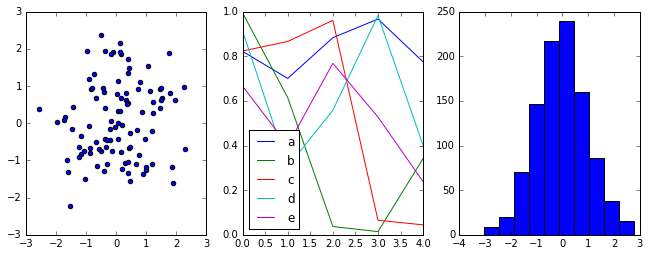

```python
graph()   #With default settings
```

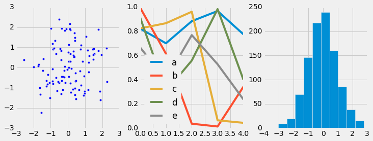

```python
with plt.style.context('fivethirtyeight'):    #Fivethirtyeight
    graph()
```

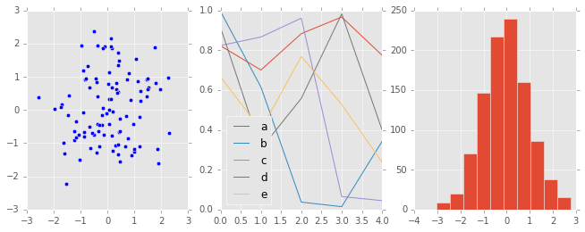

```python
with plt.style.context('ggplot'):    #Ggplot
    graph()
```

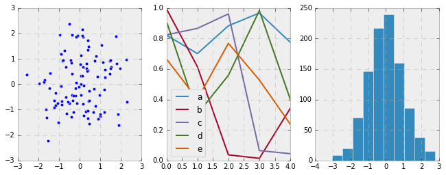

```python
with plt.style.context('bmh'):    #Bayesian Methods for Hackers
    graph()
```

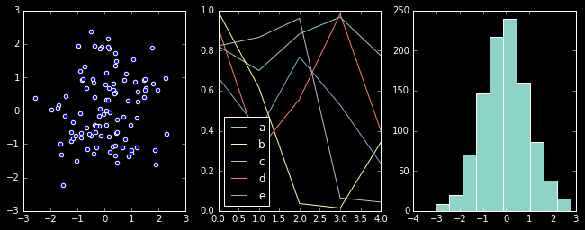

```python
with plt.style.context('dark_background'):     #Dark Background
    graph()
```

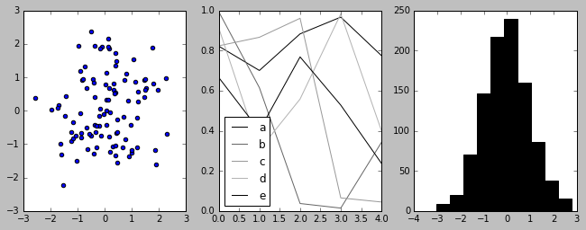

```python
with plt.style.context('grayscale'):    #Gray scale
    graph()
```

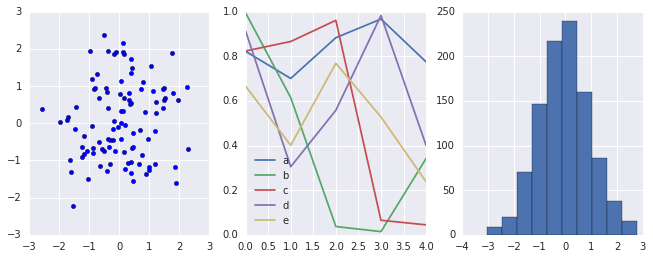

```python
import seaborn
with plt.style.context('seaborn'):    #Seaborn
    graph()
```

Task-16C: Please visualize a 3D plot with a complex trigonometric function that you are going to write as in the examples that we have covered during the class. The complex function can be similar (but not the same with the given one). Please use the following functions for your visualizations:

- Scatter function
- Counter3D function
- Plot surface function
- Plot trisurf function

Please also provide three different views for the same illustration.

Task-16C: Please visualize a 3D plot with a complex trigonometric function that you are going to write as in the examples that we have covered during the class. The complex function can be similar (but not the same with the given one). Please use the following functions for your visualizations:

- Scatter function
- Counter3D function
- Plot surface function
- Plot trisurf function

Please also provide three different views for the same illustration.

```python
from mpl_toolkits import mplot3d
```

```python
def f(x, y):
    return np.sin(np.sqrt(x ** 2 + y ** 2))

X = np.linspace(-2, 2, 50)
Y = np.linspace(-2, 2, 50)

#X, Y = np.meshgrid(x, y)
Z = f(X, Y)
```

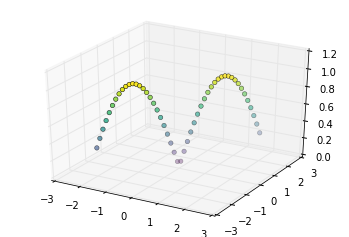

```python
ax = plt.axes(projection='3d')
ax.scatter(X, Y, Z, c=Z, cmap='viridis', linewidth=0.5);   #Scatter function
```

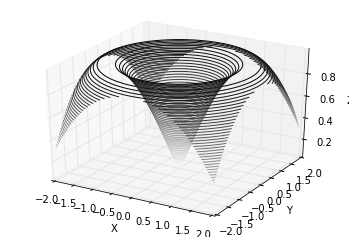

```python
fig = plt.figure()
ax = plt.axes(projection='3d')
X, Y = np.meshgrid(X, Y)
Z = f(X, Y)
ax.contour3D(X, Y, Z, 50, cmap='binary')
ax.set_xlabel('X')
ax.set_ylabel('Y')
ax.set_zlabel('Z');   #Counter3D function
```

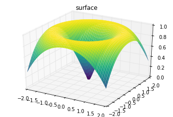

```python
ax = plt.axes(projection='3d')
ax.plot_surface(X, Y, Z, rstride=1, cstride=1,
                cmap='viridis', edgecolor='none')
ax.set_title('surface');                                #Plot surface function
```

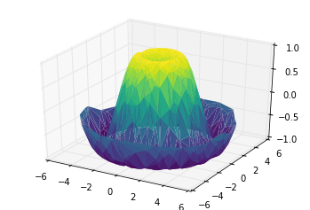

```python
theta = 2 * np.pi * np.random.random(1000)
r = 6 * np.random.random(1000)
x = np.ravel(r * np.sin(theta))
y = np.ravel(r * np.cos(theta))
z = f(x, y)

ax = plt.axes(projection='3d')
ax.plot_trisurf(x, y, z,
                cmap='viridis', edgecolor='none');             #Plot trisurf function
```

Task-16D: Please use the geographic data tools to represent the map of Turkey from different views and functions. Please annotate Ankara in a given Turkey map.

```python
from mpl_toolkits.basemap import Basemap
```

```
Clipping input data to the valid range for imshow with RGB data ([0..1] for floats or [0..255] for integers).
```

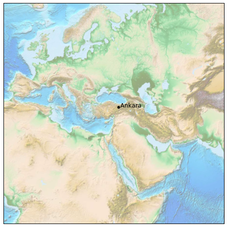

```python
fig = plt.figure(figsize=(8, 8))
m = Basemap(projection='lcc', resolution=None,
            width=8E6, height=8E6,
            lat_0=38, lon_0=36,)
m.etopo(scale=0.5, alpha=0.5)

# Map (long, lat) to (x, y) for plotting
x, y = m(38, 40)
plt.plot(x, y, 'ok', markersize=5)
plt.text(x, y, ' Ankara', fontsize=12);
```